# Credit_card_fraud_datection

```python
import pandas as pd
import warnings
warnings.filterwarnings("ignore")
```

```python
# Read the data
cc_df = pd.read_csv('creditcard.csv')
cc_df.head()
```

|  | Time | V1 | V2 | V3 | V4 | V5 | V6 | V7 | V8 | V9 | ... | V21 | V22 | V23 | V24 | V25 | V26 | V27 | V28 | Amount | Class |
| --- | --- | --- | --- | --- | --- | --- | --- | --- | --- | --- | --- | --- | --- | --- | --- | --- | --- | --- | --- | --- | --- |
| 0 | 0.0 | -1.359807 | -0.072781 | 2.536347 | 1.378155 | -0.338321 | 0.462388 | 0.239599 | 0.098698 | 0.363787 | ... | -0.018307 | 0.277838 | -0.110474 | 0.066928 | 0.128539 | -0.189115 | 0.133558 | -0.021053 | 149.62 | 0 |
| 1 | 0.0 | 1.191857 | 0.266151 | 0.166480 | 0.448154 | 0.060018 | -0.082361 | -0.078803 | 0.085102 | -0.255425 | ... | -0.225775 | -0.638672 | 0.101288 | -0.339846 | 0.167170 | 0.125895 | -0.008983 | 0.014724 | 2.69 | 0 |
| 2 | 1.0 | -1.358354 | -1.340163 | 1.773209 | 0.379780 | -0.503198 | 1.800499 | 0.791461 | 0.247676 | -1.514654 | ... | 0.247998 | 0.771679 | 0.909412 | -0.689281 | -0.327642 | -0.139097 | -0.055353 | -0.059752 | 378.66 | 0 |
| 3 | 1.0 | -0.966272 | -0.185226 | 1.792993 | -0.863291 | -0.010309 | 1.247203 | 0.237609 | 0.377436 | -1.387024 | ... | -0.108300 | 0.005274 | -0.190321 | -1.175575 | 0.647376 | -0.221929 | 0.062723 | 0.061458 | 123.50 | 0 |
| 4 | 2.0 | -1.158233 | 0.877737 | 1.548718 | 0.403034 | -0.407193 | 0.095921 | 0.592941 | -0.270533 | 0.817739 | ... | -0.009431 | 0.798278 | -0.137458 | 0.141267 | -0.206010 | 0.502292 | 0.219422 | 0.215153 | 69.99 | 0 |

5 rows × 31 columns

```python
# printing the columns
print(cc_df.columns)

# checking the shape of the data
print("Shape - ", cc_df.shape)

# checking the data types
print("Dtypes - \n", cc_df.dtypes)
```

```
Index(['Time', 'V1', 'V2', 'V3', 'V4', 'V5', 'V6', 'V7', 'V8', 'V9', 'V10',
       'V11', 'V12', 'V13', 'V14', 'V15', 'V16', 'V17', 'V18', 'V19', 'V20',
       'V21', 'V22', 'V23', 'V24', 'V25', 'V26', 'V27', 'V28', 'Amount',
       'Class'],
      dtype='object')
Shape -  (284807, 31)
Dtypes -
 Time      float64
V1        float64
V2        float64
V3        float64
V4        float64
V5        float64
V6        float64
V7        float64
V8        float64
V9        float64
V10       float64
V11       float64
V12       float64
V13       float64
V14       float64
V15       float64
V16       float64
V17       float64
V18       float64
V19       float64
V20       float64
V21       float64
V22       float64
V23       float64
V24       float64
V25       float64
V26       float64
V27       float64
V28       float64
Amount    float64
Class       int64
dtype: object
```

```python
# checking the missing values
print("Missing values \n", cc_df.isnull().sum())
```

```
Missing values
 Time      0
V1        0
V2        0
V3        0
V4        0
V5        0
V6        0
V7        0
V8        0
V9        0
V10       0
V11       0
V12       0
V13       0
V14       0
V15       0
V16       0
V17       0
V18       0
V19       0
V20       0
V21       0
V22       0
V23       0
V24       0
V25       0
V26       0
V27       0
V28       0
Amount    0
Class     0
dtype: int64
```

```python
# Checking the class distribution
print("Class distribution \n", cc_df['Class'].value_counts())
```

```
Class distribution
 Class
0    284315
1       492
Name: count, dtype: int64
```

**Dataset is highly imbalanced**

```
Numerical columns -  Index(['Time', 'V1', 'V2', 'V3', 'V4', 'V5', 'V6', 'V7', 'V8', 'V9', 'V10',
       'V11', 'V12', 'V13', 'V14', 'V15', 'V16', 'V17', 'V18', 'V19', 'V20',
       'V21', 'V22', 'V23', 'V24', 'V25', 'V26', 'V27', 'V28', 'Amount',
       'Class'],
      dtype='object')
```

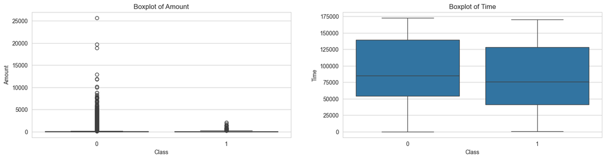

```python
# Detecting and handling outliers class-wise using whiskers
# Extract numerical columns
num_cols = cc_df.select_dtypes(include=['int64', 'float64']).columns
print("Numerical columns - ", num_cols)

# Separating the fraud and non-fraud data
fraud = cc_df[cc_df['Class'] == 1]
non_fraud = cc_df[cc_df['Class'] == 0]

# Plotting the boxplots for all the numerical columns
import matplotlib.pyplot as plt
import seaborn as sns
sns.set_style("whitegrid")
fig, ax = plt.subplots(1, 2, figsize=(18,4))
sns.boxplot(x="Class", y="Amount", data=cc_df, ax=ax[0])
ax[0].set_title("Boxplot of Amount")
sns.boxplot(x="Class", y="Time", data=cc_df, ax=ax[1])
ax[1].set_title("Boxplot of Time")
plt.show()
```

Removing outliers from minority class will make the datasaet more imbalanced. As a result we will remove outliers from only majority class

```python
# Removing outliers from the non-Fraud class
# Calculating the IQR
Q1 = non_fraud.quantile(0.25)
Q3 = non_fraud.quantile(0.75)
IQR = Q3 - Q1
print(IQR)

# Removing the outliers
non_fraud = non_fraud[~((non_fraud < (Q1 - 1.5 * IQR)) |(non_fraud > (Q3 + 1.5 * IQR))).any(axis=1)]

# Checking the shape of the data
print("Shape - ", fraud.shape)
print ("Shape - ", non_fraud.shape)
```

```
Time      85103.000000
V1            2.233762
V2            1.399919
V3            1.912914
V4            1.587700
V5            1.301579
V6            1.166466
V7            1.122461
V8            0.534833
V9            1.238642
V10           0.988015
V11           1.499809
V12           1.021310
V13           1.310559
V14           0.916557
V15           1.231654
V16           0.989281
V17           0.882566
V18           0.998517
V19           0.913865
V20           0.344165
V21           0.414135
V22           1.070809
V23           0.309225
V24           0.794294
V25           0.667739
V26           0.567746
V27           0.161425
V28           0.130911
Amount       71.400000
Class         0.000000
dtype: float64
Shape -  (492, 31)
Shape -  (145954, 31)
```

```python
# Concatenating the fraud and non-fraud data
cc_df = pd.concat([fraud, non_fraud])
```

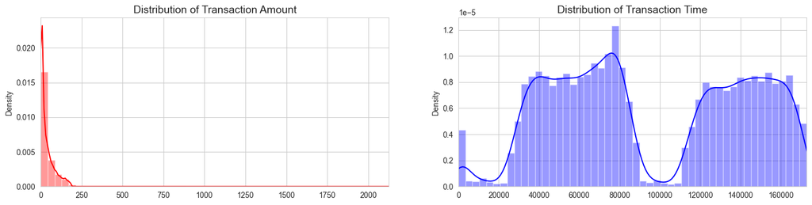

```python
# Visualizing the data
import matplotlib.pyplot as plt
import seaborn as sns

# Plot the distribution of Time and Amount

fig, ax = plt.subplots(1, 2, figsize=(18,4))

amount_val = cc_df['Amount'].values
time_val = cc_df['Time'].values

sns.distplot(amount_val, ax=ax[0], color='r')
ax[0].set_title('Distribution of Transaction Amount', fontsize=14)
ax[0].set_xlim([min(amount_val), max(amount_val)])

sns.distplot(time_val, ax=ax[1], color='b')
ax[1].set_title('Distribution of Transaction Time', fontsize=14)
ax[1].set_xlim([min(time_val), max(time_val)])

plt.show()
```

**Now the outliers are removed and data is cleaned**  
**We can use min-max scaling as it maintains distribution of the data**

```python
from sklearn.preprocessing import MinMaxScaler

# Extract the numerical features
numerical_features = ['Time', 'Amount'] + [f'V{i}' for i in range(1, 29)]

# Create a MinMaxScaler object
scaler = MinMaxScaler()

# Fit the scaler on the numerical features and transform them
cc_df[numerical_features] = scaler.fit_transform(cc_df[numerical_features])
cc_df.head()
```

|  | Time | V1 | V2 | V3 | V4 | V5 | V6 | V7 | V8 | V9 | ... | V21 | V22 | V23 | V24 | V25 | V26 | V27 | V28 | Amount | Class |
| --- | --- | --- | --- | --- | --- | --- | --- | --- | --- | --- | --- | --- | --- | --- | --- | --- | --- | --- | --- | --- | --- |
| 541 | 0.002350 | 0.855573 | 0.339927 | 0.845224 | 0.471053 | 0.650089 | 0.386613 | 0.831038 | 0.695084 | 0.635230 | ... | 0.466293 | 0.513187 | 0.760060 | 0.705758 | 0.690451 | 0.345667 | 0.729425 | 0.473055 | 0.000000 | 1 |
| 623 | 0.002732 | 0.833417 | 0.172189 | 0.922552 | 0.359665 | 0.706774 | 0.414696 | 0.889040 | 0.671179 | 0.784098 | ... | 0.469182 | 0.540466 | 0.834540 | 0.521220 | 0.724111 | 0.263296 | 0.679606 | 0.522125 | 0.248839 | 1 |
| 4920 | 0.025824 | 0.855842 | 0.333599 | 0.881050 | 0.362376 | 0.641069 | 0.491482 | 0.893836 | 0.665752 | 0.786046 | ... | 0.450065 | 0.461164 | 0.785866 | 0.583275 | 0.661747 | 0.162048 | 0.707945 | 0.470382 | 0.112862 | 1 |
| 6108 | 0.040431 | 0.792382 | 0.320439 | 0.817054 | 0.385154 | 0.631838 | 0.364875 | 0.811613 | 0.668215 | 0.785479 | ... | 0.467419 | 0.525479 | 0.761234 | 0.593442 | 0.720192 | 0.132775 | 0.623928 | 0.745169 | 0.027753 | 1 |
| 6329 | 0.043516 | 0.963017 | 0.374982 | 0.767999 | 0.518943 | 0.774977 | 0.391954 | 0.917157 | 0.664159 | 0.723821 | ... | 0.448367 | 0.474395 | 0.752310 | 0.118829 | 0.897092 | 0.444797 | 0.703139 | 0.552555 | 0.000470 | 1 |

5 rows × 31 columns

**Analyzing fraud vs non-fraud transactions**

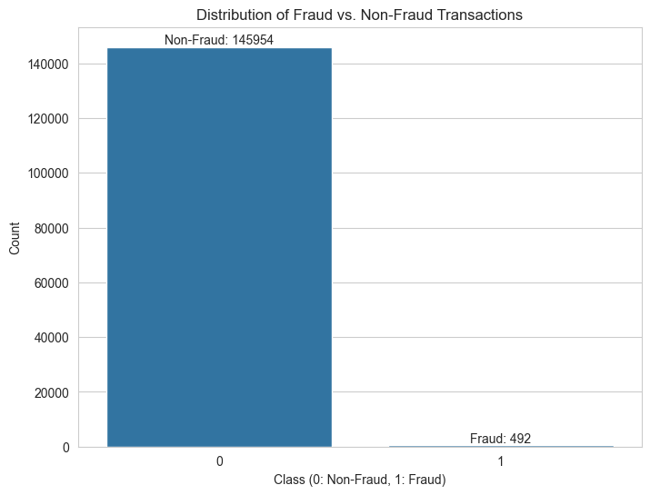

```python
#fraud vs non-fraud visualization

plt.figure(figsize=(8, 6))

# Countplot to visualize the distribution of fraud vs. non-fraud transactions
sns.countplot(x='Class', data=cc_df)
plt.title('Distribution of Fraud vs. Non-Fraud Transactions')
plt.xlabel('Class (0: Non-Fraud, 1: Fraud)')
plt.ylabel('Count')

# Display the count of each class
fraud_count = cc_df['Class'].value_counts()[1]
non_fraud_count = cc_df['Class'].value_counts()[0]
plt.text(0, non_fraud_count, f'Non-Fraud: {non_fraud_count}', ha='center', va='bottom')
plt.text(1, fraud_count, f'Fraud: {fraud_count}', ha='center', va='bottom')

plt.show()
```

***Still it is a highly imbalanced dataset***

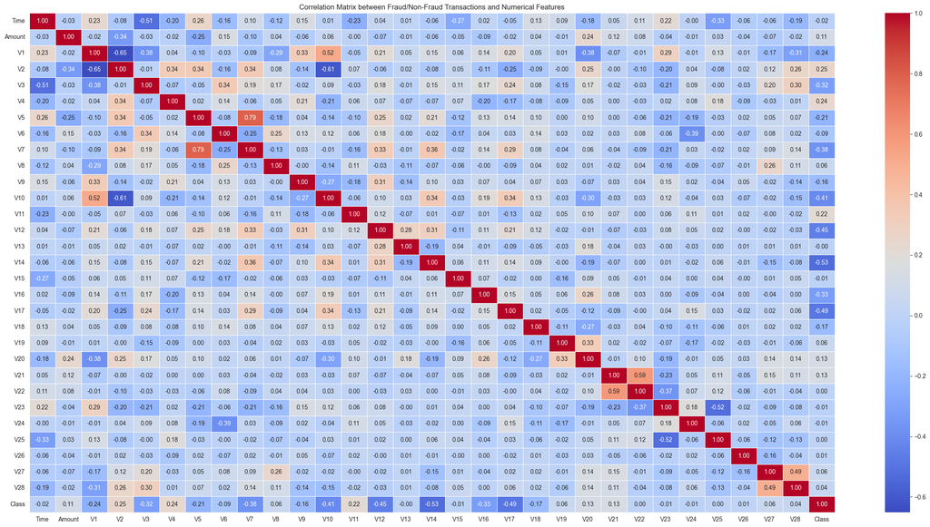

```python
##Identifying the correlation fraud/non-fraud to other features
plt.figure(figsize=(30, 15))

# Selecting numerical features
numerical_features = ['Time', 'Amount'] + [f'V{i}' for i in range(1, 29)]

# Adding the target variable 'Class' to the correlation matrix
correlation_matrix = cc_df[numerical_features + ['Class']].corr()

# Heatmap to visualize the correlation matrix
sns.heatmap(correlation_matrix, annot=True, cmap='coolwarm', fmt=".2f", linewidths=0.5)
plt.title('Correlation Matrix between Fraud/Non-Fraud Transactions and Numerical Features')
plt.show()
```

```python
# Printing the correlation matrix
print(correlation_matrix['Class'].abs().sort_values(ascending=False))
```

```
Class     1.000000
V14       0.527810
V17       0.488891
V12       0.452934
V10       0.409616
V7        0.375428
V16       0.325954
V3        0.316223
V2        0.250124
V1        0.244726
V4        0.236476
V11       0.217516
V5        0.207426
V18       0.173157
V9        0.163916
V21       0.130744
V20       0.126141
Amount    0.113374
V6        0.090780
V27       0.064314
V8        0.062318
V19       0.059561
V28       0.044565
Time      0.018354
V23       0.013083
V24       0.011648
V15       0.009739
V26       0.009070
V22       0.004549
V13       0.001972
V25       0.001971
Name: Class, dtype: float64
```

***Top 3 Features having highest correlation with the target variables are V14, V17 and V12 whereas V25 is the feature having lowest correaltion with class feature***

**Correlation matrix gives us the features having highest correlation with the target variable in order**

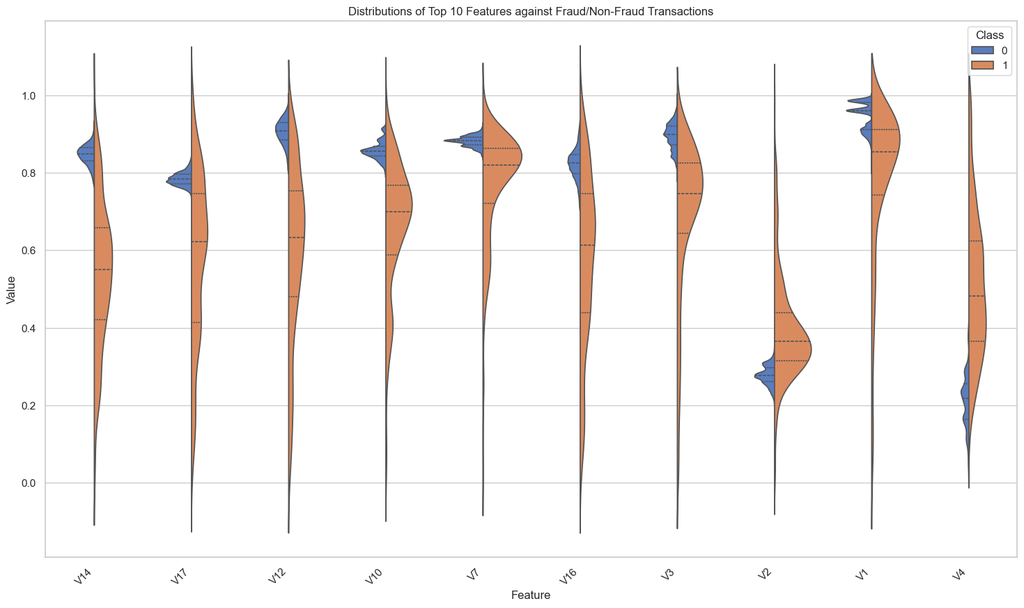

```python
##Plotting the top 10 features having highest correlation with 'Class'

# Get the top 10 features with highest correlation with 'Class'
top_features = correlation_matrix['Class'].abs().sort_values(ascending=False)[1:11].index.tolist()

# Select only the relevant columns for visualization
selected_data = cc_df[['Class'] + list(top_features)]

# Melt the DataFrame to create a 'tidy' format for seaborn
melted_data = pd.melt(selected_data, id_vars='Class', var_name='Feature', value_name='Value')

# Plot distributions of the top features for fraud and non-fraud transactions
plt.figure(figsize=(18, 10))
sns.set(style="whitegrid")

# Use a violin plot for visualization
sns.violinplot(x='Feature', y='Value', hue='Class', data=melted_data, split=True, inner='quart', palette='muted')
plt.title('Distributions of Top 10 Features against Fraud/Non-Fraud Transactions')
plt.xlabel('Feature')
plt.ylabel('Value')

plt.xticks(rotation=45, ha='right')  # Rotate x-axis labels for better readability
plt.show()
```

```python
##Splitting the data into train and test with class weights
from sklearn.model_selection import train_test_split

# Create the X and y set
X = cc_df.drop('Class', axis=1)
y = cc_df['Class']

# Split the data into train and test sets
X_train, X_test, y_train, y_test = train_test_split(X, y, stratify=y, test_size=0.2, random_state=0)

# Print the shapes of the train and test sets
print("Shape of X_train - ", X_train.shape)
print("Shape of y_train - ", y_train.shape)
print("Shape of X_test - ", X_test.shape)
print("Shape of y_test - ", y_test.shape)

# Print the class distribution in the train and test sets
print("Class distribution in y_train - \n", y_train.value_counts())
print("Class distribution in y_test - \n", y_test.value_counts())
```

```
Shape of X_train -  (117156, 30)
Shape of y_train -  (117156,)
Shape of X_test -  (29290, 30)
Shape of y_test -  (29290,)
Class distribution in y_train -
 Class
0    116762
1       394
Name: count, dtype: int64
Class distribution in y_test -
 Class
0    29192
1       98
Name: count, dtype: int64
```

**Training logistic regression as a baseline model**

```python
from sklearn.model_selection import cross_val_predict
from sklearn.linear_model import LogisticRegression
from sklearn.metrics import accuracy_score, precision_score, recall_score, f1_score

# Train a logistic regression model with 5-fold cross-validation
baseline_model = LogisticRegression(random_state=42)
y_pred_cv = cross_val_predict(baseline_model, X_train, y_train, cv=5)

# Evaluate performance metrics on the training set
accuracy_cv = accuracy_score(y_train, y_pred_cv)
precision_cv = precision_score(y_train, y_pred_cv)
recall_cv = recall_score(y_train, y_pred_cv)
f1_cv = f1_score(y_train, y_pred_cv)

# Print the results on the training set
print("Cross-validated performance on the training set:")
print(f"Accuracy: {accuracy_cv:.4f}")
print(f"Precision: {precision_cv:.4f}")
print(f"Recall: {recall_cv:.4f}")
print(f"F1-Score: {f1_cv:.4f}")

# Evaluate the model on the test set
baseline_model.fit(X_train, y_train)  # Fit the model on the entire training set
y_pred_test = baseline_model.predict(X_test)

# Evaluate performance metrics on the test set
accuracy_test = accuracy_score(y_test, y_pred_test)
precision_test = precision_score(y_test, y_pred_test)
recall_test = recall_score(y_test, y_pred_test)
f1_test = f1_score(y_test, y_pred_test)

# Print the results on the test set
print("\nPerformance on the test set:")
print(f"Accuracy: {accuracy_test:.4f}")
print(f"Precision: {precision_test:.4f}")
print(f"Recall: {recall_test:.4f}")
print(f"F1-Score: {f1_test:.4f}")
```

```
Cross-validated performance on the training set:
Accuracy: 0.9991
Precision: 1.0000
Recall: 0.7335
F1-Score: 0.8463

Performance on the test set:
Accuracy: 0.9988
Precision: 1.0000
Recall: 0.6531
F1-Score: 0.7901
```

```python
# Access feature names and their coefficients
coefficients = baseline_model.coef_[0]
feature_names = X_train.columns

# Create a dictionary to store feature names and their corresponding coefficients
feature_coefficients = dict(zip(feature_names, coefficients))

# Print feature names and their coefficients, sorted by coefficient magnitude
sorted_features = sorted(feature_coefficients.items(), key=lambda x: abs(x[1]), reverse=True)

print("Feature weights:")
for feature, coef in sorted_features:
    print(f"{feature}: {coef:.4f}")
```

```
Feature weights:
V14: -9.8594
V4: 9.2350
V12: -7.5566
V11: 5.2243
Amount: 4.4295
V3: -3.6979
V1: -3.6832
V10: -3.6010
V16: -2.9641
V9: -2.5123
V6: -1.7044
V17: -1.6380
V7: -0.9407
V24: -0.9239
V19: -0.8940
V13: -0.8630
V5: 0.7387
V28: 0.6502
V2: 0.6039
V25: -0.5930
V20: 0.5907
V15: -0.5272
V8: -0.5025
V22: 0.4926
V21: 0.4338
V23: -0.2399
V27: 0.2355
Time: 0.2236
V18: -0.0131
V26: 0.0062
```

Which shows that model gives higher weight to the **V14** feature as it has highest correlation with the target feature

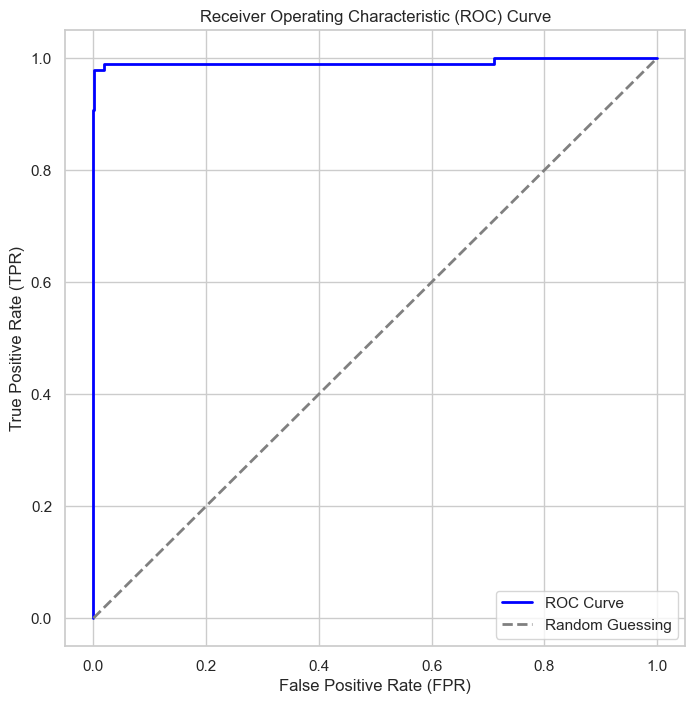

```
AUC: 0.9925
```

```python
from sklearn.metrics import roc_curve, roc_auc_score
import matplotlib.pyplot as plt

# Make predictions on the test set
y_prob = baseline_model.predict_proba(X_test)[:, 1]

# Calculate the ROC curve
fpr, tpr, thresholds = roc_curve(y_test, y_prob)

# Plot the ROC curve
plt.figure(figsize=(8, 8))
plt.plot(fpr, tpr, color='blue', lw=2, label='ROC Curve')
plt.plot([0, 1], [0, 1], color='gray', linestyle='--', lw=2, label='Random Guessing')

plt.title('Receiver Operating Characteristic (ROC) Curve')
plt.xlabel('False Positive Rate (FPR)')
plt.ylabel('True Positive Rate (TPR)')
plt.legend()
plt.show()

# Calculate the AUC
auc = roc_auc_score(y_test, y_prob)
print(f"AUC: {auc:.4f}")
```

According to ROC curve the model is better at just random guessing which is also indicated by the value of AUC

**Applying SMOTE technique to handle the class imbalance**

```python
from imblearn.over_sampling import SMOTE
from sklearn.model_selection import train_test_split
from sklearn.metrics import accuracy_score, precision_score, recall_score, f1_score, roc_auc_score
from sklearn.linear_model import LogisticRegression

X_train, X_test, y_train, y_test = train_test_split(X, y, test_size=0.2, random_state=42)

# Apply SMOTE to the training set
smote = SMOTE(random_state=42)
X_train_smote, y_train_smote = smote.fit_resample(X_train, y_train)

# Train a logistic regression model without SMOTE
baseline_model = LogisticRegression(random_state=42)
baseline_model.fit(X_train, y_train)

# Train a logistic regression model with SMOTE
model_with_smote = LogisticRegression(random_state=42)
model_with_smote.fit(X_train_smote, y_train_smote)

# Evaluate performance without SMOTE
y_pred_baseline = baseline_model.predict(X_test)
auc_baseline = roc_auc_score(y_test, baseline_model.predict_proba(X_test)[:, 1])

# Evaluate performance with SMOTE
y_pred_smote = model_with_smote.predict(X_test)
auc_smote = roc_auc_score(y_test, model_with_smote.predict_proba(X_test)[:, 1])

# Print results
print("Without SMOTE:")
print(f"AUC: {auc_baseline:.4f}")
print("Performance metrics:")
print(f"Accuracy: {accuracy_score(y_test, y_pred_baseline):.4f}")
print(f"Precision: {precision_score(y_test, y_pred_baseline):.4f}")
print(f"Recall: {recall_score(y_test, y_pred_baseline):.4f}")
print(f"F1-Score: {f1_score(y_test, y_pred_baseline):.4f}")

print("\nWith SMOTE:")
print(f"AUC: {auc_smote:.4f}")
print("Performance metrics:")
print(f"Accuracy: {accuracy_score(y_test, y_pred_smote):.4f}")
print(f"Precision: {precision_score(y_test, y_pred_smote):.4f}")
print(f"Recall: {recall_score(y_test, y_pred_smote):.4f}")
print(f"F1-Score: {f1_score(y_test, y_pred_smote):.4f}")
```

```
Without SMOTE:
AUC: 0.9836
Performance metrics:
Accuracy: 0.9992
Precision: 1.0000
Recall: 0.7798
F1-Score: 0.8763

With SMOTE:
AUC: 0.9848
Performance metrics:
Accuracy: 0.9931
Precision: 0.3390
Recall: 0.9083
F1-Score: 0.4938
```

The increase in recall after applying SMOTE indicates that the model is now able to identify more instances of the minority class, reducing false negatives.  
The decrease in precision suggests an increase in false positives, as reflected in the low F1-Score.

```python
# Training the model with ADASYN
from imblearn.over_sampling import ADASYN
from sklearn.model_selection import train_test_split
from sklearn.metrics import accuracy_score, precision_score, recall_score, f1_score, roc_auc_score
from sklearn.linear_model import LogisticRegression

X_train, X_test, y_train, y_test = train_test_split(X, y, test_size=0.2, random_state=42)

# Apply ADASYN to the training set
adasyn = ADASYN(random_state=42)
X_train_ada, y_train_ada = adasyn.fit_resample(X_train, y_train)

# Train a logistic regression model without ADASYN
baseline_model = LogisticRegression(random_state=42)
baseline_model.fit(X_train, y_train)

# Train a logistic regression model with ADASYN
model_with_ada = LogisticRegression(random_state=42)
model_with_ada.fit(X_train_ada, y_train_ada)

# Evaluate performance without ADASYN
y_pred_baseline = baseline_model.predict(X_test)
auc_baseline = roc_auc_score(y_test, baseline_model.predict_proba(X_test)[:, 1])

# Evaluate performance with ADASYN
y_pred_ada = model_with_ada.predict(X_test)
auc_ada = roc_auc_score(y_test, model_with_ada.predict_proba(X_test)[:, 1])

# Print results
print("Without ADASYN:")
print(f"AUC: {auc_baseline:.4f}")
print("Performance metrics:")
print(f"Accuracy: {accuracy_score(y_test, y_pred_baseline):.4f}")
print(f"Precision: {precision_score(y_test, y_pred_baseline):.4f}")
print(f"Recall: {recall_score(y_test, y_pred_baseline):.4f}")
print(f"F1-Score: {f1_score(y_test, y_pred_baseline):.4f}")

print("\nWith ADASYN:")
print(f"AUC: {auc_ada:.4f}")
print("Performance metrics:")
print(f"Accuracy: {accuracy_score(y_test, y_pred_ada):.4f}")
print(f"Precision: {precision_score(y_test, y_pred_ada):.4f}")
print(f"Recall: {recall_score(y_test, y_pred_ada):.4f}")
print(f"F1-Score: {f1_score(y_test, y_pred_ada):.4f}")
```

```
Without ADASYN:
AUC: 0.9836
Performance metrics:
Accuracy: 0.9992
Precision: 1.0000
Recall: 0.7798
F1-Score: 0.8763

With ADASYN:
AUC: 0.9849
Performance metrics:
Accuracy: 0.9561
Precision: 0.0758
Recall: 0.9633
F1-Score: 0.1405
```

```python
# Training the model with SMOTEENN
from imblearn.combine import SMOTEENN
from sklearn.model_selection import train_test_split
from sklearn.metrics import accuracy_score, precision_score, recall_score, f1_score, roc_auc_score
from sklearn.linear_model import LogisticRegression

X_train, X_test, y_train, y_test = train_test_split(X, y, test_size=0.2, random_state=42)

# Apply SMOTEENN to the training set
smote_enn = SMOTEENN(random_state=42)
X_train_smoteenn, y_train_smoteenn = smote_enn.fit_resample(X_train, y_train)

# Train a logistic regression model without SMOTEENN
baseline_model = LogisticRegression(random_state=42)
baseline_model.fit(X_train, y_train)

# Train a logistic regression model with SMOTEENN
model_with_smoteenn = LogisticRegression(random_state=42)
model_with_smoteenn.fit(X_train_smoteenn, y_train_smoteenn)

# Evaluate performance without SMOTEENN
y_pred_baseline = baseline_model.predict(X_test)
auc_baseline = roc_auc_score(y_test, baseline_model.predict_proba(X_test)[:, 1])

# Evaluate performance with SMOTEENN
y_pred_smoteenn = model_with_smoteenn.predict(X_test)
auc_smoteenn = roc_auc_score(y_test, model_with_smoteenn.predict_proba(X_test)[:, 1])

# Print results
print("Without SMOTEENN:")
print(f"AUC: {auc_baseline:.4f}")
print("Performance metrics:")
print(f"Accuracy: {accuracy_score(y_test, y_pred_baseline):.4f}")
print(f"Precision: {precision_score(y_test, y_pred_baseline):.4f}")
print(f"Recall: {recall_score(y_test, y_pred_baseline):.4f}")
print(f"F1-Score: {f1_score(y_test, y_pred_baseline):.4f}")

print("\nWith SMOTEENN:")
print(f"AUC: {auc_smoteenn:.4f}")
print("Performance metrics:")
print(f"Accuracy: {accuracy_score(y_test, y_pred_smoteenn):.4f}")
print(f"Precision: {precision_score(y_test, y_pred_smoteenn):.4f}")
print(f"Recall: {recall_score(y_test, y_pred_smoteenn):.4f}")
print(f"F1-Score: {f1_score(y_test, y_pred_smoteenn):.4f}")
```

```
Without SMOTEENN:
AUC: 0.9836
Performance metrics:
Accuracy: 0.9992
Precision: 1.0000
Recall: 0.7798
F1-Score: 0.8763

With SMOTEENN:
AUC: 0.9839
Performance metrics:
Accuracy: 0.9930
Precision: 0.3379
Recall: 0.9083
F1-Score: 0.4925
```

```python
# Training the model with SMOTETomek
from imblearn.combine import SMOTETomek
from sklearn.model_selection import train_test_split
from sklearn.metrics import accuracy_score, precision_score, recall_score, f1_score, roc_auc_score
from sklearn.linear_model import LogisticRegression

X_train, X_test, y_train, y_test = train_test_split(X, y, test_size=0.2, random_state=42)

# Apply SMOTETomek to the training set
smote_tomek = SMOTETomek(random_state=42)
X_train_smotetomek, y_train_smotetomek = smote_tomek.fit_resample(X_train, y_train)

# Train a logistic regression model with SMOTETomek
model_with_smotetomek = LogisticRegression(random_state=42)
model_with_smotetomek.fit(X_train_smotetomek, y_train_smotetomek)

# Evaluate performance with SMOTETomek
y_pred_smotetomek = model_with_smotetomek.predict(X_test)
auc_smotetomek = roc_auc_score(y_test, model_with_smotetomek.predict_proba(X_test)[:, 1])

# Print results
print("With SMOTETomek:")
print(f"AUC: {auc_smotetomek:.4f}")
print("Performance metrics:")
print(f"Accuracy: {accuracy_score(y_test, y_pred_smotetomek):.4f}")
print(f"Precision: {precision_score(y_test, y_pred_smotetomek):.4f}")
print(f"Recall: {recall_score(y_test, y_pred_smotetomek):.4f}")
print(f"F1-Score: {f1_score(y_test, y_pred_smotetomek):.4f}")
```

```
With SMOTETomek:
AUC: 0.9848
Performance metrics:
Accuracy: 0.9931
Precision: 0.3390
Recall: 0.9083
F1-Score: 0.4938
```

Results explains SMOTEENN and SMOTETomek are almost similar

```python
# Training the model with RandomOverSampler and RandomUnderSampler
from imblearn.over_sampling import RandomOverSampler
from imblearn.under_sampling import RandomUnderSampler
from sklearn.model_selection import train_test_split
from sklearn.metrics import accuracy_score, precision_score, recall_score, f1_score, roc_auc_score
from sklearn.linear_model import LogisticRegression

X_train, X_test, y_train, y_test = train_test_split(X, y, test_size=0.2, random_state=42)

# Apply RandomOverSampler to minority class and RandomUnderSampler to majority class in the training set
ros = RandomOverSampler(random_state=42)
X_train_ros, y_train_ros = ros.fit_resample(X_train, y_train)
rus = RandomUnderSampler(random_state=42)
X_train_ros_rus, y_train_ros_rus = rus.fit_resample(X_train_ros, y_train_ros)

# Train a logistic regression model with RandomOverSampler and RandomUnderSampler
model_with_ros_rus = LogisticRegression(random_state=42)
model_with_ros_rus.fit(X_train_ros_rus, y_train_ros_rus)

# Evaluate performance with RandomOverSampler and RandomUnderSampler
y_pred_ros_rus = model_with_ros_rus.predict(X_test)
auc_ros_rus = roc_auc_score(y_test, model_with_ros_rus.predict_proba(X_test)[:, 1])

# Print results
print("With RandomOverSampler:")
print(f"AUC: {auc_ros_rus:.4f}")
print("Performance metrics:")
print(f"Accuracy: {accuracy_score(y_test, y_pred_ros_rus):.4f}")
print(f"Precision: {precision_score(y_test, y_pred_ros_rus):.4f}")
print(f"Recall: {recall_score(y_test, y_pred_ros_rus):.4f}")
print(f"F1-Score: {f1_score(y_test, y_pred_ros_rus):.4f}")
```

```
With RandomOverSampler:
AUC: 0.9863
Performance metrics:
Accuracy: 0.9938
Precision: 0.3640
Recall: 0.9083
F1-Score: 0.5197
```

Combining Random over sampling and undersampling the data resulted in a little high f1-score which is better and recall of 90% gives it is anow able to capture most of the datapoints. However having low precision is an issue which is a tradeoff for recall.

```python
# training a random forest model with random oversampling and random undersampling techhniques
from imblearn.over_sampling import RandomOverSampler
from imblearn.under_sampling import RandomUnderSampler
from sklearn.model_selection import train_test_split
from sklearn.metrics import accuracy_score, precision_score, recall_score, f1_score, roc_auc_score
from sklearn.ensemble import RandomForestClassifier

X_train, X_test, y_train, y_test = train_test_split(X, y, test_size=0.2, random_state=42)

ros = RandomOverSampler(random_state=42, sampling_strategy=0.4)
X_train_ros, y_train_ros = ros.fit_resample(X_train, y_train)
rus = RandomUnderSampler(random_state=42)
X_train_ros_rus, y_train_ros_rus = rus.fit_resample(X_train_ros, y_train_ros)

# Train a random forest model with RandomOverSampler and RandomUnderSampler
model_with_ros_rus = RandomForestClassifier(random_state=42)
model_with_ros_rus.fit(X_train_ros_rus, y_train_ros_rus)

# Evaluate performance with RandomOverSampler and RandomUnderSampler
y_pred_ros_rus = model_with_ros_rus.predict(X_test)
auc_ros_rus = roc_auc_score(y_test, model_with_ros_rus.predict_proba(X_test)[:, 1])

# Print results
print("With RandomOverSampler:")
print(f"AUC: {auc_ros_rus:.4f}")
print("Performance metrics:")
print(f"Accuracy: {accuracy_score(y_test, y_pred_ros_rus):.4f}")
print(f"Precision: {precision_score(y_test, y_pred_ros_rus):.4f}")
print(f"Recall: {recall_score(y_test, y_pred_ros_rus):.4f}")
print(f"F1-Score: {f1_score(y_test, y_pred_ros_rus):.4f}")
```

```
With RandomOverSampler:
AUC: 0.9900
Performance metrics:
Accuracy: 0.9997
Precision: 1.0000
Recall: 0.9083
F1-Score: 0.9519
```

**Thus Switching the model to Random Forest with Random Oversampling and Random Undersampling techniques gives us a better performance than the Logistic Regression model. With a slightly hypertuning the parameters higher results can be achieved**

Still nothing beats an original data then synthetic data generation